# Table of Contents

## Data Description:

##### Amazon Reviews data The repository has several datasets. For this case study, we are using the Electronics dataset.

## Domain:

## Context:

##### Online E-commerce websites like Amazon, Flipkart uses different recommendation models to provide different suggestions to different users. Amazon currently uses item-to-item collaborative filtering, which scales to massive data sets and produces high-quality recommendations in real-time.

## Attribute Information:

- userId : Every user identified with a unique id
- productId : Every product identified with a unique id
- Rating : Rating of the corresponding product by the corresponding user
- timestamp : Time of the rating ( ignore this column for this exercise)

## Learning Outcomes:

- Exploratory Data Analysis
- Creating a Recommendation system using real data
- Collaborative filtering

## Objective

##### Build a recommendation system to recommend products to customers based on the their previous ratings for other products.

# Importing Libraries and reading file as pandas dataframe

```python
import numpy as np #import numpy
import pandas as pd #import pandas
import seaborn as sns # import seaborn
import matplotlib.pyplot as plt #import pyplot
from surprise import KNNWithMeans,SVD,KNNBaseline,KNNBasic,KNNWithZScore,BaselineOnly #import algorithms
from surprise import Dataset
from surprise import accuracy #import accuracy
from surprise import Reader #import reader
from surprise.model_selection import cross_validate #cross validate from surprise
import surprise #import surprise
from sklearn import model_selection #model selection from surprise
from collections import defaultdict #importing defaultdict
from surprise.model_selection import GridSearchCV #import gridsearchCV
from surprise.model_selection import cross_validate #import cross validate
import os, io #import os and io
from IPython.display import Image #import image
```

```python
df = pd.read_csv('ratings_Electronics.csv',names=['userId','productId','Rating','timestamp'])
#reading the CSV file and assigning column names
```

# EDA

## Shape of Dataframe

```python
print('\033[1m''Number of rows in dataframe',df.shape[0]) #for number of rows
print('\033[1m''Number of features in dataframe',df.shape[1]) #for number of features
```

```
Number of rows in dataframe 7824482
Number of features in dataframe 4
```

- The dataframe has 7824482 rows and 4 features

## Datatype of each attribute

```python
df.dtypes.to_frame('Datatypes of attributes').T #for datatypes of attributes
```

|  | userId | productId | Rating | timestamp |
| --- | --- | --- | --- | --- |
| Datatypes of attributes | object | object | float64 | int64 |

- 2 features have object type, and 2 features are numerical.

## Missing value Test

```python
df.isnull().sum().to_frame('Presence of missing values').T #for checking presence of missing values
```

|  | userId | productId | Rating | timestamp |
| --- | --- | --- | --- | --- |
| Presence of missing values | 0 | 0 | 0 | 0 |

- Missing values are not present in the dataset

## Unique value Test

```python
df.nunique().to_frame('Count of unique values').T #for checking presence of unique values
```

|  | userId | productId | Rating | timestamp |
| --- | --- | --- | --- | --- |
| Count of unique values | 4201696 | 476002 | 5 | 5489 |

- In the dataset,unique users are 4201696, unique productId are 476002 , unique Rating are 5, unique timestamp are 5489

## Distribution

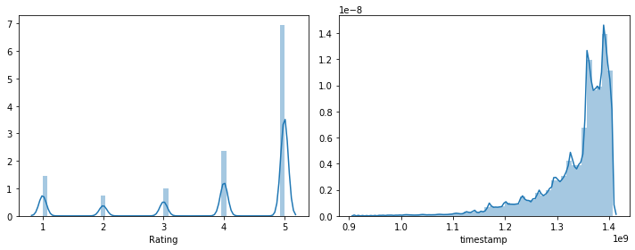

```python
fig, axe = plt.subplots(nrows=1, ncols=2, figsize=(10, 4)) #creating subplot
axe = axe.flatten() #to flatten subplot index positions
sns.distplot(df['Rating'],ax=axe[0]) #plot
sns.distplot(df['timestamp'],ax=axe[1]) #plot
fig.tight_layout() #for arranging the plots
fig.show() #display plots
```

### Understanding from distriution

- The range of ratings is 1 to 5, and the count of 5 rating is higher than all other ratings.
- Timestamp is left skewed.

## Product Ratings Distribution

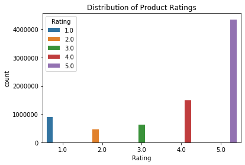

```python
sns.countplot(x=df['Rating'],data=df,hue=df['Rating']) #countplot of rating
plt.title('Distribution of Product Ratings') #title
```

## Number of Ratings per Product (top 100 products)

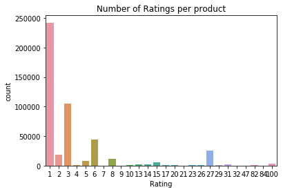

```python
data = df.groupby('productId')['Rating'].count().clip(upper=100) #top 100 products
sns.countplot(x=data.values,data=data) #countplot of ratings per product
plt.title('Number of Ratings per product') #title
```

```python
df.groupby('productId')['Rating'].count().reset_index().sort_values('Rating', ascending=False)[:10]
#selecting top 10 products with high rating count
```

|  | productId | Rating |
| --- | --- | --- |
| 308398 | B0074BW614 | 18244 |
| 429572 | B00DR0PDNE | 16454 |
| 327308 | B007WTAJTO | 14172 |
| 102804 | B0019EHU8G | 12285 |
| 296625 | B006GWO5WK | 12226 |
| 178601 | B003ELYQGG | 11617 |
| 178813 | B003ES5ZUU | 10276 |
| 323013 | B007R5YDYA | 9907 |
| 289775 | B00622AG6S | 9823 |
| 30276 | B0002L5R78 | 9487 |

### Understanding from distriution

- The highest count of ratings for a product('B0074BW614') is 18244 ratings.

## Number of Ratings per user (top 100 users)

[figure not shown]

```python
data = df.groupby('userId')['Rating'].count().clip(upper=100) #top 100 users
sns.countplot(x=data.values,data=data)#plot
plt.title('Number of Ratings per User')#title
```

```python
df.groupby('userId')['Rating'].count().reset_index().sort_values('Rating', ascending=False)[:10]
#seleccting top 10 active users
```

|  | userId | Rating |
| --- | --- | --- |
| 3263531 | A5JLAU2ARJ0BO | 520 |
| 3512451 | ADLVFFE4VBT8 | 501 |
| 2989526 | A3OXHLG6DIBRW8 | 498 |
| 3291008 | A6FIAB28IS79 | 431 |
| 3284634 | A680RUE1FDO8B | 406 |
| 755206 | A1ODOGXEYECQQ8 | 380 |
| 2424036 | A36K2N527TXXJN | 314 |
| 1451394 | A2AY4YUOX2N1BQ | 311 |
| 4100926 | AWPODHOB4GFWL | 308 |
| 1277963 | A25C2M3QF9G7OQ | 296 |

### Understanding from distriution

- The most active user('A5JLAU2ARJ0BO') has rated 520 products.
- Most users have rated 2 products.
- Majority of users have rated less than 3 products.

# Data Preprocessing

## Taking subset of dataset

```python
filter_product = df['productId'].value_counts() > 50 #product ids with more than 50 ratings
filter_product = filter_product[filter_product].index.tolist()
filter_users = df['userId'].value_counts() > 50 #user ids with more than 50 ratings given
filter_users = filter_users[filter_users].index.tolist()

df_new = df[(df['productId'].isin(filter_product)) & (df['userId'].isin(filter_users))] #selecting records based on above filters
print('\033[1m''The original data frame shape:\t{}'.format(df.shape))#original dataset shape
print('\033[1m''The new data frame shape:\t{}'.format(df_new.shape))#filtered dataset shape
```

```
The original data frame shape:	(7824482, 4)
The new data frame shape:	(76359, 4)
```

## Unique value Test

```python
df_new.nunique().to_frame('Count of unique values').T #for checking presence of unique values
```

|  | userId | productId | Rating | timestamp |
| --- | --- | --- | --- | --- |
| Count of unique values | 1466 | 16555 | 5 | 3973 |

- In the dataset,unique users are 1466, unique productId are 16555, unique Rating are 5, unique timestamp are 3973

## Train test split

```python
poptrain,poptest = model_selection.train_test_split(df_new,test_size=0.30,random_state=1)#train test split using scikit learn
```

```python
poptrain.head() #head of trainset
```

|  | userId | productId | Rating | timestamp |
| --- | --- | --- | --- | --- |
| 5682086 | A3VBXQKRM7A4JR | B0079UAT0A | 5.0 | 1355529600 |
| 7682785 | A4WEZJOIZIV4U | B00G6CLN3Y | 5.0 | 1394668800 |
| 3312298 | A196JN53PG0C7R | B003ES5ZSW | 3.0 | 1359590400 |
| 1743694 | A5KMMY627T3W | B00168BSEW | 5.0 | 1245974400 |
| 6594553 | A22S7D0LP8GRDH | B009E6J1BU | 4.0 | 1390435200 |

# Model Building

## Popularity Based Recommender

```python
mean_ratings = pd.DataFrame(poptrain.groupby('productId')['Rating'].mean()) #mean ratings
mean_ratings['rating_counts'] = pd.DataFrame(poptrain.groupby('productId')['Rating'].count())  #count of ratings
```

```python
mean_ratings = mean_ratings.sort_values(by='rating_counts', ascending=False) #sorting in descending order
rating_final_df = mean_ratings[mean_ratings.rating_counts >= 100] #selecting ratings more than 50
rating_final_df =pd.DataFrame(rating_final_df ) #creating dataframe
```

```python
rating_final_df.sort_values(by='rating_counts', ascending=False) #sorting in descending order
rating_final_df['Rank'] = rating_final_df['Rating'].rank(ascending=0, method='first') #adding ranks
rating_final_df=rating_final_df.sort_values(by='Rank',ascending=True)#sort ascending by rank
#dfCount=dfCount.rename(columns={"Rating": "Mean_rating"})
rating_final_df=rating_final_df.head(5) #top 5 recommendations
rating_final_df
```

| productId | Rating | rating_counts | Rank |
| --- | --- | --- | --- |
| B003ES5ZUU | 4.849206 | 126 | 1.0 |
| B000N99BBC | 4.798319 | 119 | 2.0 |
| B007WTAJTO | 4.647619 | 105 | 3.0 |
| B00829TIEK | 4.400000 | 100 | 4.0 |
| B0088CJT4U | 4.218543 | 151 | 5.0 |

- Above 'Rating' column is mean rating of the product.
- Above recommendations are top 5 high rated products with minimum of 100 ratings received.
- Mean rating of a product should be higher in order to term it as top rated.
- The rank column is used to recommend top 5 ranked items

### Recommending top 5 products

```python
total_users = set(poptrain['userId'])

def recommend(user_id):
    if user_id in total_users :

        print('\033[1m''UserID is from trainset with following recommendations.')
        recommendations_5 = rating_final_df

        #Add user_id column for which the recommendations are being generated
        recommendations_5['userID'] = user_id

        #Bring user_id column to the front
        cols = recommendations_5.columns.tolist()
        cols = cols[-1:] + cols[:-1]
        recommendations_5 = recommendations_5[cols]
        return recommendations_5
    else:
        print('\033[1m''UserID is from either test set or It is a New User with following recommendations.')
        recommendations_5 = rating_final_df

        #Add user_id column for which the recommendations are being generated
        recommendations_5['userID'] = user_id

        #Bring user_id column to the front
        cols = recommendations_5.columns.tolist()
        cols = cols[-1:] + cols[:-1]
        recommendations_5 = recommendations_5[cols]
        return recommendations_5
```

```python
print(recommend(112)) #recommendation for user not in trainset
```

```
UserID is from either test set or It is a New User with following recommendations.
            userID    Rating  rating_counts  Rank
productId
B003ES5ZUU     112  4.849206            126   1.0
B000N99BBC     112  4.798319            119   2.0
B007WTAJTO     112  4.647619            105   3.0
B00829TIEK     112  4.400000            100   4.0
B0088CJT4U     112  4.218543            151   5.0
```

```python
print(recommend('A3VBXQKRM7A4JR')) #recommendation for user in trainset
```

```
UserID is from trainset with following recommendations.
                    userID    Rating  rating_counts  Rank
productId
B003ES5ZUU  A3VBXQKRM7A4JR  4.849206            126   1.0
B000N99BBC  A3VBXQKRM7A4JR  4.798319            119   2.0
B007WTAJTO  A3VBXQKRM7A4JR  4.647619            105   3.0
B00829TIEK  A3VBXQKRM7A4JR  4.400000            100   4.0
B0088CJT4U  A3VBXQKRM7A4JR  4.218543            151   5.0
```

- In popularity based recommender system, all recommendations are the same because it aims to recommend the items without using the past data and the products which are high rated are recommended to solve the cold start problem.
- The drawback is, this model does not offer personalized recommendations.
- The personalized recommendations are achieved by using collaberative filtering techniques.

## Data Preparation for collaberative filtering

### Reading dataframe in surprise library

```python
reader = Reader(rating_scale=(1, 5)) #reader with rating scale 1 to 5
data = Dataset.load_from_df(df_new[['userId', 'productId', 'Rating']], reader) #reading from dataframe
```

- As the collaberative filtering models from surprise library need n_items and n_users features in the dataset, the data must be read using surprise libraries methods for reading and splitting the data.

### Train Test Split (70:30)

```python
trainset, testset = surprise.model_selection.train_test_split(data, test_size=0.30,random_state=1) #train test split using surprise library
```

## Collaberative Filtering Recommendation

### item-item collaberative filtering using KNNWithMeans

```python
algo = KNNWithMeans(k=50, sim_options={'name': 'pearson_baseline', 'user_based': False}) #knnwithmeans item based,k=50
algo.fit(trainset) #fit on train data
```

```
Estimating biases using als...
Computing the pearson_baseline similarity matrix...
Done computing similarity matrix.
```

```
<surprise.prediction_algorithms.knns.KNNWithMeans at 0x21b840948d0>
```

```python
test_pred = algo.test(testset) #prediction on test data
```

```python
# RMSE on test data
print('\033[1m''RMSE on test data of KNN with means item-item collaberative filtering: {:.2f}'.format(accuracy.rmse(test_pred, verbose=True)))
```

```
RMSE: 1.1188
RMSE on test data of KNN with means item-item collaberative filtering: 1.12
```

#### Function to recommend top 5 products

```python
def recommend5(predictions, topN = 5): #function definition

    recommendations = defaultdict(list) #create a dicttionary of list type
    for uid, iid, true_r, est, _ in predictions: #for loop
        recommendations[uid].append((iid, est))#append id

    for uid, user_ratings in recommendations.items():#for loop
        user_ratings.sort(key = lambda x: x[1], reverse = True)#sort ratings
        recommendations[uid] = user_ratings[:topN]#select top 5

    return recommendations #return
```

```python
def read_item_names(): #function definition
    file_name = ('ratings_Electronics.csv')#store filename
    names = {}#empty dictionary
    with io.open(file_name, 'r', encoding='ISO-8859-1') as f: #open file
        for line in f: #read data linewise
            line = line.split(',')#split using ','
            names[line[1]] = line[1]#assign value

    return names #return
```

#### predicting items using item-item collaberative filtering

```python
Predictions=[] #list to store predictions
recommendations = recommend5(test_pred)#recommend function call
names = read_item_names()#get all values
for uid, user_ratings in recommendations.items():#for loop
    Predictions.append(([uid,[names[iid] for (iid, _) in user_ratings]])) #append predictions
```

```python
User_DF=pd.DataFrame(Predictions,columns=['UserId','Prediction'])#create a dataframe of predictions
Predictions=pd.DataFrame(User_DF.Prediction.tolist(), columns=['Recommendation1', 'Recommendation2', 'Recommendation3', 'Recommendation4', 'Recommendation5'])#split values
concat=pd.concat([User_DF['UserId'],Predictions],axis=1)#concatenate dataframes
concat.head(100)#top 100 user wise predictions
```

|  | UserId | Recommendation1 | Recommendation2 | Recommendation3 | Recommendation4 | Recommendation5 |
| --- | --- | --- | --- | --- | --- | --- |
| 0 | AL1XV4L25FZ2S | B004RO9L4Q | B002Y6CJJ8 | B001QUA6R0 | B002RWJD7A | B0002XQDSS |
| 1 | AGR1V15L6FLMA | B004HHICKC | B002SQ9ZX2 | B007WTAJTO | B009OBCAW2 | B00081A2KY |
| 2 | A1VQBEW0G4IH1J | B00EOE4G4E | B004NBZ8DQ | B006K553LU | B0028LK6IU | B004DKVRDM |
| 3 | AGVWTYW0ULXHT | B00FP3OX3C | B0052N9HWM | B002O3KVSC | B001144JQU | B0002XN3VS |
| 4 | A1S27P7KJO9I96 | B00486MH80 | B00083JQY0 | B000SDNMHW | B004444O5U | B00EOE4G4E |
| ... | ... | ... | ... | ... | ... | ... |
| 95 | AROQO2VDODT7 | B000KO0GY6 | B0000BZL1P | B0007DDK7A | B002W3IXZW | B00007E7JU |
| 96 | A1SC5OXLQNGPLN | B0033PRWSW | B00007GQLU | B0015LURY2 | B0054JJ0QW | B00D5Q75RC |
| 97 | AX05DBU8IRUWY | B00C57P2BI | B00H4OWPE4 | B000J1H4VI | B00IKCQ0EK | B00AD9RLJ6 |
| 98 | A2W9I628I6SE1U | B008HY8XTG | B000ANCPNM | B000TKHBDK | B000GHTGES | B00FRDUZXM |
| 99 | A1L64KDYO5BOJA | B0038JECL8 | B001CN7EQ2 | B00009XVCZ | B00DMS0GTC | B00378YPB2 |

100 rows × 6 columns

- Above are predictions are of top 100 userIDs, also all userIDs have personalized recommendations which can be observed by looking at the whole dataframe.

### user-user Collaberative filtering using KNNwithMeans

```python
algo = KNNWithMeans(k=50, sim_options={'name': 'pearson_baseline', 'user_based': True})#knnwithmeans item based,k=50
algo.fit(trainset)#fit on train data
test_pred = algo.test(testset)#prediction on test data
```

```
Estimating biases using als...
Computing the pearson_baseline similarity matrix...
Done computing similarity matrix.
```

```python
# get RMSE
print('\033[1m''RMSE on test data of KNN with means user-user collaberative filtering: {:.2f}'.format(accuracy.rmse(test_pred, verbose=True)))
```

```
RMSE: 1.0201
RMSE on test data of KNN with means user-user collaberative filtering: 1.02
```

#### Predicting items with user-user collaberative filtering

```python
Predictions=[] #list to store predictions
recommendations = recommend5(test_pred)#recommend function call
names = read_item_names()#get all values
for uid, user_ratings in recommendations.items():#for loop
    Predictions.append(([uid,[names[iid] for (iid, _) in user_ratings]])) #append predictions
```

```python
User_DF=pd.DataFrame(Predictions,columns=['UserId','Prediction'])#create a dataframe of predictions
Predictions=pd.DataFrame(User_DF.Prediction.tolist(), columns=['Recommendation1', 'Recommendation2', 'Recommendation3', 'Recommendation4', 'Recommendation5'])#split values
concat=pd.concat([User_DF['UserId'],Predictions],axis=1)#concatenate dataframes
concat.head(100)#top 100 user wise predictions
```

|  | UserId | Recommendation1 | Recommendation2 | Recommendation3 | Recommendation4 | Recommendation5 |
| --- | --- | --- | --- | --- | --- | --- |
| 0 | AL1XV4L25FZ2S | B001QUA6R0 | B000BKLNHS | B000TXZIDM | B001QXDN5O | B00CHT6CRC |
| 1 | AGR1V15L6FLMA | B004HHICKC | B007WTAJTO | B003690Q42 | B00081A2KY | B008VMT2HQ |
| 2 | A1VQBEW0G4IH1J | B0028LK6IU | B004DKVRDM | B00BQ5RY1G | B00EOE4G4E | B009QV72VY |
| 3 | AGVWTYW0ULXHT | B0011N180Q | B00CQJUT9U | B00E8CF0CE | B00BERGFV6 | B001ASU1QO |
| 4 | A1S27P7KJO9I96 | B005HY4UIW | B003YKFKR6 | B00EOE4G4E | B004444O5U | B007KZQM9G |
| ... | ... | ... | ... | ... | ... | ... |
| 95 | AROQO2VDODT7 | B000KO0GY6 | B000VY2BC0 | B002W3IXZW | B0000BZL1P | B004J3Y9U6 |
| 96 | A1SC5OXLQNGPLN | B00007GQLU | B0054JJ0QW | B0033PRWSW | B00D5Q75RC | B0015LURY2 |
| 97 | AX05DBU8IRUWY | B005I7X3RC | B00IKCQ0EK | B00C57P2BI | B003ZBZ64Q | B00HZWJGS8 |
| 98 | A2W9I628I6SE1U | B00829TIEK | B000TKHBDK | B0082E9K7U | B0071BTJPI | B000GHTGES |
| 99 | A1L64KDYO5BOJA | B000P1O73A | B00009XVCZ | B0038JECL8 | B001MSVPM6 | B001EQ4C8U |

100 rows × 6 columns

- The difference between user based and item based filtering's RMSE of KNNWithMeans algorithm is 0.1, which depicts that the recommendations will be somewhat similar in both techniques.

# Cross validation and hyperparameter tuning

## Cross validation of multiple algorithms from surprise library

```python
Scores = [] #empty list
for algorithm in [SVD(), KNNWithMeans(), KNNWithZScore(), BaselineOnly(),KNNBaseline(), KNNBasic()]:#for loop to iterate
    results = cross_validate(algorithm, data, measures=['RMSE'], cv=3, verbose=False) #cross validation
    #apppend results
    tmp = pd.DataFrame.from_dict(results).mean(axis=0)
    tmp = tmp.append(pd.Series([str(algorithm).split(' ')[0].split('.')[-1]], index=['Algorithm']))
    Scores.append(tmp)

Scores=pd.DataFrame(Scores).set_index('Algorithm').sort_values('test_rmse') #create dataframe
```

[output not shown]

```python
Scores #display scores
```

| Algorithm | test_rmse | fit_time | test_time |
| --- | --- | --- | --- |
| BaselineOnly | 0.953893 | 0.108214 | 0.171163 |
| SVD | 0.959759 | 2.607885 | 0.192705 |
| KNNBaseline | 1.040254 | 0.194106 | 0.656272 |
| KNNWithMeans | 1.041769 | 0.113786 | 0.558882 |
| KNNWithZScore | 1.051029 | 0.164547 | 0.636228 |
| KNNBasic | 1.102153 | 0.086385 | 0.608247 |

- Baselineonly ans SVD have obtained lowest RMSE scores.
- KNNBaseline has lowest RMSE amongst all KNN based models.
- Let's try to imrpove the performance of models using hyperparameter tuning

## Hyperparameter tuning of baselineonly

```python
param_grid = {'bsl_options':{'method': ['als','sgd'],'n_epochs':[5,10,15],'reg_u': [10,15,20],'reg_i': [5,10,15]}}#parameters
gs = GridSearchCV(BaselineOnly, param_grid=param_grid, measures=['rmse'], cv=3)#grid search
gs.fit(data)#fit
algo = gs.best_estimator['rmse']#set best estimators
print(gs.best_score['rmse'])#print best rmse
print(gs.best_params['rmse'])#print best parameters
```

[output not shown]

[output cut: 109 more lines]

[output not shown]

```python
bsl_options= {'method': 'sgd', 'n_epochs': 15, 'reg_u': 10, 'reg_i': 5} #parameters
algo = BaselineOnly(bsl_options=bsl_options) #baselineonly
algo.fit(trainset)#train the model
test_pred = algo.test(testset)#predict on testdata

# get RMSE
print('\033[1m''RMSE on test data of KNN with means item-item collaberative filtering: {:.2f}'.format(accuracy.rmse(test_pred, verbose=True)))
```

```
Estimating biases using sgd...
RMSE: 0.9467
RMSE on test data of KNN with means item-item collaberative filtering: 0.95
```

## Hyperparameter tuning of KNNBaseline

### item-item collaberative filtering

```python
param_grid = {'k':[50,60,70],'sim_options':{'name': ['pearson_baseline','cosine'],'user_based':[False]}}#parameter grid
gs = GridSearchCV(KNNBaseline, param_grid=param_grid, measures=['rmse'], cv=3)#grid search
gs.fit(data)#fit
algo = gs.best_estimator['rmse']#set best estimators
print(gs.best_score['rmse'])#print best rmse
print(gs.best_params['rmse'])#print best parameters
```

[output not shown]

#### Using the best hyperparameters to train the model

```python
algo = KNNBaseline(k=50, sim_options={'name': 'pearson_baseline', 'user_based': False})#model
algo.fit(trainset)#train
test_pred = algo.test(testset) #predict on testdata
```

```
Estimating biases using als...
Computing the pearson_baseline similarity matrix...
Done computing similarity matrix.
```

```python
# get RMSE
print('\033[1m''RMSE on test data of KNNbaseline item-item collaberative filtering: {:.2f}'.format(accuracy.rmse(test_pred, verbose=True)))
```

```
RMSE: 0.9923
RMSE on test data of KNNbaseline item-item collaberative filtering: 0.99
```

```python
Predictions=[] #list to store predictions
recommendations = recommend5(test_pred)#recommend function call
names = read_item_names()#get all values
for uid, user_ratings in recommendations.items():#for loop
    Predictions.append(([uid,[names[iid] for (iid, _) in user_ratings]])) #append predictions
```

```python
User_DF=pd.DataFrame(Predictions,columns=['UserId','Prediction'])#create a dataframe of predictions
Predictions=pd.DataFrame(User_DF.Prediction.tolist(), columns=['Recommendation1', 'Recommendation2', 'Recommendation3', 'Recommendation4', 'Recommendation5'])#split values
concat=pd.concat([User_DF['UserId'],Predictions],axis=1)#concatenate dataframes
concat.head(100)#top 100 user wise predictions
```

|  | UserId | Recommendation1 | Recommendation2 | Recommendation3 | Recommendation4 | Recommendation5 |
| --- | --- | --- | --- | --- | --- | --- |
| 0 | AL1XV4L25FZ2S | B002Y6CJJ8 | B001QUA6R0 | B00DDK1QUC | B002RWJD7A | B004RO9L4Q |
| 1 | AGR1V15L6FLMA | B004HHICKC | B007WTAJTO | B001QUA6R0 | B00081A2KY | B009OBCAW2 |
| 2 | A1VQBEW0G4IH1J | B00EOE4G4E | B006K553LU | B004NBZ8DQ | B0028LK6IU | B004DKVRDM |
| 3 | AGVWTYW0ULXHT | B0050A1O5U | B0011N180Q | B004I5FL1G | B006FNCWSY | B005IMFX2K |
| 4 | A1S27P7KJO9I96 | B00486MH80 | B004444O5U | B00EOE4G4E | B00EMB4LU8 | B007KZQM9G |
| ... | ... | ... | ... | ... | ... | ... |
| 95 | AROQO2VDODT7 | B002W3IXZW | B000KO0GY6 | B0000BZL1P | B00007E7JU | B0007DDK7A |
| 96 | A1SC5OXLQNGPLN | B00007GQLU | B0054JJ0QW | B0033PRWSW | B00D5Q75RC | B001S2PPT0 |
| 97 | AX05DBU8IRUWY | B00609B3J2 | B00HZWJGS8 | B00IKCQ0EK | B000J1H4VI | B005I7X3RC |
| 98 | A2W9I628I6SE1U | B0082E9K7U | B000ANCPNM | B0071BTJPI | B000TKHBDK | B008HY8XTG |
| 99 | A1L64KDYO5BOJA | B00009XVCZ | B0019EHU8G | B00DMS0GTC | B00180LGX6 | B000P1O73A |

100 rows × 6 columns

### user-user collaberative filtering

```python
param_grid = {'k':[50,60,70],'sim_options':{'name': ['pearson_baseline','cosine'],'user_based':[True]}} #parameter grid
gs = GridSearchCV(KNNBaseline, param_grid=param_grid, measures=['rmse'], cv=3)#gridsearch
gs.fit(data)#fit
algo = gs.best_estimator['rmse']#set best estimators
print(gs.best_score['rmse'])#print best rmse
print(gs.best_params['rmse'])#print best parameters
```

[output not shown]

#### Using the best hyperparameters to train the model

```python
algo = KNNBaseline(k=50, sim_options={'name': 'pearson_baseline', 'user_based': True})#model
algo.fit(trainset)#train
test_pred = algo.test(testset)#predict on testdata
```

```
Estimating biases using als...
Computing the pearson_baseline similarity matrix...
Done computing similarity matrix.
```

```python
# get RMSE
print('\033[1m''RMSE on test data of KNNbaseline user-user collaberative filtering: {:.2f}'.format(accuracy.rmse(test_pred, verbose=True)))
```

```
RMSE: 1.0055
RMSE on test data of KNNbaseline user-user collaberative filtering: 1.01
```

```python
Predictions=[] #list to store predictions
recommendations = recommend5(test_pred)#recommend function call
names = read_item_names()#get all values
for uid, user_ratings in recommendations.items():#for loop
    Predictions.append(([uid,[names[iid] for (iid, _) in user_ratings]])) #append predictions
```

```python
User_DF=pd.DataFrame(Predictions,columns=['UserId','Prediction'])#create a dataframe of predictions
Predictions=pd.DataFrame(User_DF.Prediction.tolist(), columns=['Recommendation1', 'Recommendation2', 'Recommendation3', 'Recommendation4', 'Recommendation5'])#split values
concat=pd.concat([User_DF['UserId'],Predictions],axis=1)#concatenate dataframes
concat.head(100)#top 100 user wise predictions
```

|  | UserId | Recommendation1 | Recommendation2 | Recommendation3 | Recommendation4 | Recommendation5 |
| --- | --- | --- | --- | --- | --- | --- |
| 0 | AL1XV4L25FZ2S | B001QUA6R0 | B002Y6CJJ8 | B004RO9L4Q | B0002XQDSS | B00CMQTVK0 |
| 1 | AGR1V15L6FLMA | B004HHICKC | B007WTAJTO | B003690Q42 | B001QUA6R0 | B00081A2KY |
| 2 | A1VQBEW0G4IH1J | B00BQ5RY1G | B009QV72VY | B00EOE4G4E | B00DIOALPE | B004NBZ8DQ |
| 3 | AGVWTYW0ULXHT | B0011N180Q | B00CQJUT9U | B00BERGFV6 | B00E8CF0CE | B001ASU1QO |
| 4 | A1S27P7KJO9I96 | B005HY4UIW | B003YKFKR6 | B00EOE4G4E | B004444O5U | B0013AV4M4 |
| ... | ... | ... | ... | ... | ... | ... |
| 95 | AROQO2VDODT7 | B000KO0GY6 | B002W3IXZW | B000VY2BC0 | B0007DDK7A | B0017U0WM8 |
| 96 | A1SC5OXLQNGPLN | B00007GQLU | B0033PRWSW | B00D5Q75RC | B0015LURY2 | B0054JJ0QW |
| 97 | AX05DBU8IRUWY | B005I7X3RC | B00IKCQ0EK | B00C57P2BI | B003ZBZ64Q | B00HZWJGS8 |
| 98 | A2W9I628I6SE1U | B00829TIEK | B000TKHBDK | B0082E9K7U | B0071BTJPI | B000GHTGES |
| 99 | A1L64KDYO5BOJA | B000P1O73A | B00009XVCZ | B0019EHU8G | B00DMS0GTC | B00180LGX6 |

100 rows × 6 columns

## SVD

```python
algo = SVD(n_factors=160, n_epochs=100, lr_all=0.005, reg_all=0.1)#model
algo.fit(trainset)#train
test_pred = algo.test(testset)#prediction on test data
```

```python
# get RMSE
print('\033[1m''RMSE on test data of SVD: {:.2f}'.format(accuracy.rmse(test_pred, verbose=True)))
```

```
RMSE: 0.9567
RMSE on test data of SVD: 0.96
```

```python
Predictions=[] #list to store predictions
recommendations = recommend5(test_pred)#recommend function call
names = read_item_names()#get all values
for uid, user_ratings in recommendations.items():#for loop
    Predictions.append(([uid,[names[iid] for (iid, _) in user_ratings]])) #append predictions
```

```python
User_DF=pd.DataFrame(Predictions,columns=['UserId','Prediction'])#create a dataframe of predictions
Predictions=pd.DataFrame(User_DF.Prediction.tolist(), columns=['Recommendation1', 'Recommendation2', 'Recommendation3', 'Recommendation4', 'Recommendation5'])#split values
concat=pd.concat([User_DF['UserId'],Predictions],axis=1)#concatenate dataframes
concat.head(100)#top 100 user wise predictions
```

|  | UserId | Recommendation1 | Recommendation2 | Recommendation3 | Recommendation4 | Recommendation5 |
| --- | --- | --- | --- | --- | --- | --- |
| 0 | AL1XV4L25FZ2S | B001QUA6R0 | B002Y6CJJ8 | B002RWJD7A | B000TXZIDM | B00CMQTVK0 |
| 1 | AGR1V15L6FLMA | B009OBCAW2 | B00081A2KY | B001QUA6R0 | B004HHICKC | B008DVMRXG |
| 2 | A1VQBEW0G4IH1J | B006K553LU | B004NBZ8DQ | B00EOE4G4E | B0028LK6IU | B004DKVRDM |
| 3 | AGVWTYW0ULXHT | B001FA1NZK | B00A81SXHI | B002O3KVSC | B000E6NGBU | B00CQJUT9U |
| 4 | A1S27P7KJO9I96 | B007KZQM9G | B000SDNMHW | B0013AV4M4 | B00083JQY0 | B004444O5U |
| ... | ... | ... | ... | ... | ... | ... |
| 95 | AROQO2VDODT7 | B0000BZL1P | B0007DDK7A | B002W3IXZW | B0017U0WM8 | B000KO0GY6 |
| 96 | A1SC5OXLQNGPLN | B0033PRWSW | B0054JJ0QW | B00D5Q75RC | B00007GQLU | B0015LURY2 |
| 97 | AX05DBU8IRUWY | B00IKCQ0EK | B000J1H4VI | B00609B3J2 | B00C57P2BI | B0082E9K7U |
| 98 | A2W9I628I6SE1U | B000TKHBDK | B000ANCPNM | B0082E9K7U | B0071BTJPI | B004YLCFCM |
| 99 | A1L64KDYO5BOJA | B00DMS0GTC | B0019EHU8G | B003N12TSY | B001QEPR5M | B001MSVPM6 |

100 rows × 6 columns

# Recommendation Comparison of Models

```
KNNbaseline item-item collaberative filtering (RMSE=0.99)  5 recommendations for first 5 users:
```

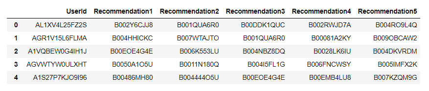

```python
print('\033[1m''KNNbaseline item-item collaberative filtering (RMSE=0.99)  5 recommendations for first 5 users:')
Image(filename='KNNitem.PNG',width=800,height=600) #include Image
```

```
KNNbaseline user-user collaberative filtering (RMSE=1.01)  5 recommendations for first 5 users:
```

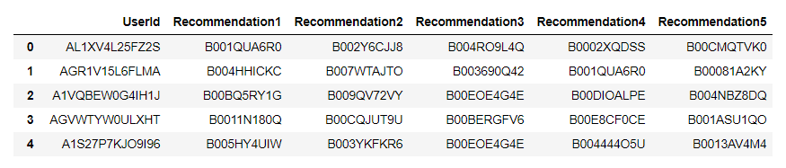

```python
print('\033[1m''KNNbaseline user-user collaberative filtering (RMSE=1.01)  5 recommendations for first 5 users:')
Image(filename='KNNuser.PNG',width=800,height=600) #include Image
```

```
SVD (RMSE=0.96) 5 recommendations for first 5 users:
```

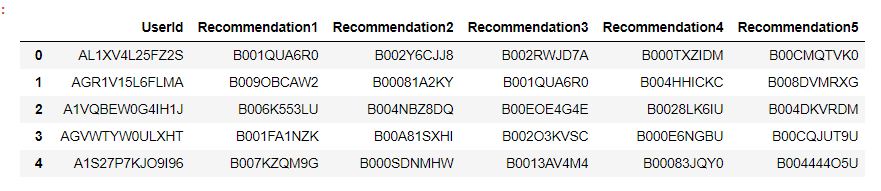

```python
print('\033[1m''SVD (RMSE=0.96) 5 recommendations for first 5 users:')
Image(filename='SVD.PNG',width=800,height=600) #include Image
```

- Above are the recommendations of top 5 userIDs for KNNbaseline and SVD models.
- As SVD has lower RMSE than KNNBaseline, recommendations of SVD are a bit more accurate.
- The recommendations are somewhat similar as the difference between RMSE of KNNbaseline and SVD is not much significant.

# Conclusion:

- Insights and comments are already added after each step. These are some additives in the documentation.

## Comments on Models:

- Baselineonly and SVD produced lowest RMSE while in KNN based models KNNbaseline produced lowest RMSE.
- As per theory, lowest RMSE is expected from models so for this dataset any algorithm from baselineonly, SVD and KNNbaseline can be chosen; But KNNbaseline should be preffered as it provides an easy way to configure models for user based or item based collaberative filtering.
- Recommendations for each model differ as their Error values differ.
- A difference is noticeable on the recommendations based on user/item based model.
- SVD has higher time complexity than other models.

## Miscellaneous comments:

- The Execution of large dataset without applying filters was causing 'memory error' while executing.
- The correlationplot,pairplot do not provide significant insights into this kind of dataset, also these plots have huge time complexity so they are not included in this analysis.

References:

- https://surprise.readthedocs.io/en/stable/basic_algorithms.html
- https://surprise.readthedocs.io/en/stable/knn_inspired.html
- https://surprise.readthedocs.io/en/stable/matrix_factorization.html
- https://surprise.readthedocs.io/en/stable/model_selection.html#cross-validation
- https://surprise.readthedocs.io/en/stable/model_selection.html#parameter-search